# SY01 - TP6 - Julien Calonne - Leonard Grandry - Mathieu Hervé

## Introduction au TP

Ce TP a été réalisé par *Julien CALONNE, Léonard GRANDRY et Mathieu HERVE.*  
Nous avions d’abord travaillé de notre côté étant lors des séances de TP mais nous avons ensuite collaboré pour réussir les questions plus complexes. Nous rendons donc ce document tous les 3.  
Il est important pour afficher correctement le rendu d’ouvrir depuis RStudio le fichier Rmd et de faire un rendu complet en HTML avec Knit  
Les questions et exercices du sommaire sont cliquables pour un accès plus rapide.  
Nous avons également utilisé la synthaxe LaTeX pour afficher correctement les partie théorique indépendante du language R.

# Sommaire

## Exercice 1

### ⊛ Question 1

### ⊛ Question 2

### ⊛ Question 3

## Exercice 2

### ⊛ Question 4

### ⊛ Question 5

### ⊛ Question 6

### ⊛ Question 7

## Exercice 3

### ⊛ Question 8

### ⊛ Question 9

### ⊛ Question 10

# Exercice 1

#### Le nombre de visiteurs quotidiens à Disneyland Paris suit une loi de Poisson de paramètre 10000.

#### Chaque visiteur entre dans le parc par une des dix entrées E1, …, E10, qu’il choisit de manière équiprobable et indépendamment des autres visiteurs.

## Question 1

Déterminer le nombre moyen de visiteurs en une journée.

Le nombre de visiteurs quotidiens à Disneyland Paris suit une loi de Poisson de paramètre 10 000, on en déduit donc que le nombre moyen de visiteurs en une journée est de 10 000.

On peut également retrouver ce resultat par le calcul, où l’on trouve également une moyenne quotidienne de 10 000 :

```r
res <- rpois(365,lambda=10000)
mean(res)
```

```
## [1] 9997.025
```

## Question 2

#### On désigne par N le nombre de visiteurs en une journée et X1 le nombre de visiteurs entrant par E1 durant cette journée.

a) Déterminer la loi conditionnelle à [N=n] de X1.

Si n est le nombre de personnes entrant dans le parc, on a donc k personnes passant par l’entrée E1, avec k compris entre 0 et n. Il y a 10 portes d’entrée, la probabilité qu’une personne passe par la porte E1 est de 1/10.

X1 compte le nombre de personnes passant par la porte E1 dans une journée : on peut assimiler cela au nombre de succès d’une expérience aléatoire. On peut donc dire que X1 suit une loi binomiale de paramètres (n,1/10).

b) En déduire la loi conjointe de N et X1, puis la loi de X1.

#### Loi conjointe de (N,X1) :

On sait que la loi conjointe de paramètre (N,X1) est l’ensemble des P[(N=n)∩(X1=k)]. Nous distinguons 2 cas:

#### *1er cas, pour k>n :*

On a
$$\mathbb{P}[(N=n)∩(X_{1}=k)] = 0$$
car on ne peut pas avoir plus de visiteurs rentrant par E1 que de nombre de visiteurs total entrant dans le parc.

#### *2ème cas, pour k<n :*

$$\mathbb{P}[(N=n)∩(X_{1}=k)]=\mathbb{P}(N=n) * \mathbb{P}(X_{1}=k)= e^{-10000} * \frac{10000^n}{n!} * \frac{n!}{k!(n-k)!} * (\frac{1}{10})^{k} * \frac{9}{10}^{(n-k)}$$

#### Loi de X1 :

On cherche à avoir toutes les probabilités telles que les visiteurs passent par E1. Ainsi on a

$$\mathbb{P}(X_{1}=k)=\sum_{n=k}^{+\infty }\mathbb{P}[(N=n)∩(X_{1}=k)]= e^{-1000}*\frac{1000^{k}}{k!}$$

#### On peut alors en déduire que X1 suit une loi de poisson de paramètre 1000.

c) En déduire l’espérance et la variance de X1.

```r
X1=rpois(1000,1000)
#La Variance est égale à l'Esperance car X1 suit une loi de poisson donc :
E_X1=V_X1=mean(X1)
#Esperance
E_X1
```

```
## [1] 1001.057
```

```r
#Variance
V_X1
```

```
## [1] 1001.057
```

## Question 3

Sachant qu’un visiteur sur dix se débrouille pour entrer sans payer, calculer le nombre moyen de visiteurs qui payent et entrent par E1 par jour.

#### On sait que le nombre de visiteurs qui entrent par E1 par jour suit une loi de Poisson de paramètre λ = 1000.

#### Supposons que n visiteurs entrent par l’entrée E1 et notons Y le nombre de ces visiteurs qui payent.

#### Chaque visiteur va alors soit payer (avec une probabilité de 9/10) soit non (probabilité de 1/10). Cette épreuve est répétée n fois, de manière indépendante. Y compte donc le nombre de succès de cette expérience; Y suit une loi binomiale de paramètres (n,9/10).

#### Y suit donc une loi de poisson de paramètre 1000*(9/10)=900

#### On obtient donc l’espérance de cette loi, qui est de 900.

# Exercice 2 - Binomiale et Poisson

## Question 4

Générer aléatoirement deux vecteurs contenant 1000 réalisations de X et Y. On prendra λ=2 et μ=3

```r
#Création des vecteurs
vecX <- c(rpois(1000,2))
vecY <- c(rpois(1000,3))
```

## Question 5

Construire ensuite le vecteur contenant les valeurs de Z

```r
vecZ <- c(vecX+vecY)

#On calcule la moyenne pour vérifier quel avoisine bien 5 (car λ=2 et μ=3) :
mean(vecZ)
```

```
## [1] 4.993
```

## Question 6

a. Représenter graphiquement la distribution de Z

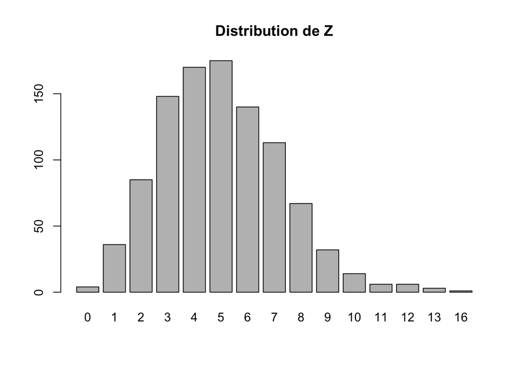

```r
barplot(table(vecZ),main='Distribution de Z')
```

b. Ajouter à la représentation précédente la distribution théorique attendue.

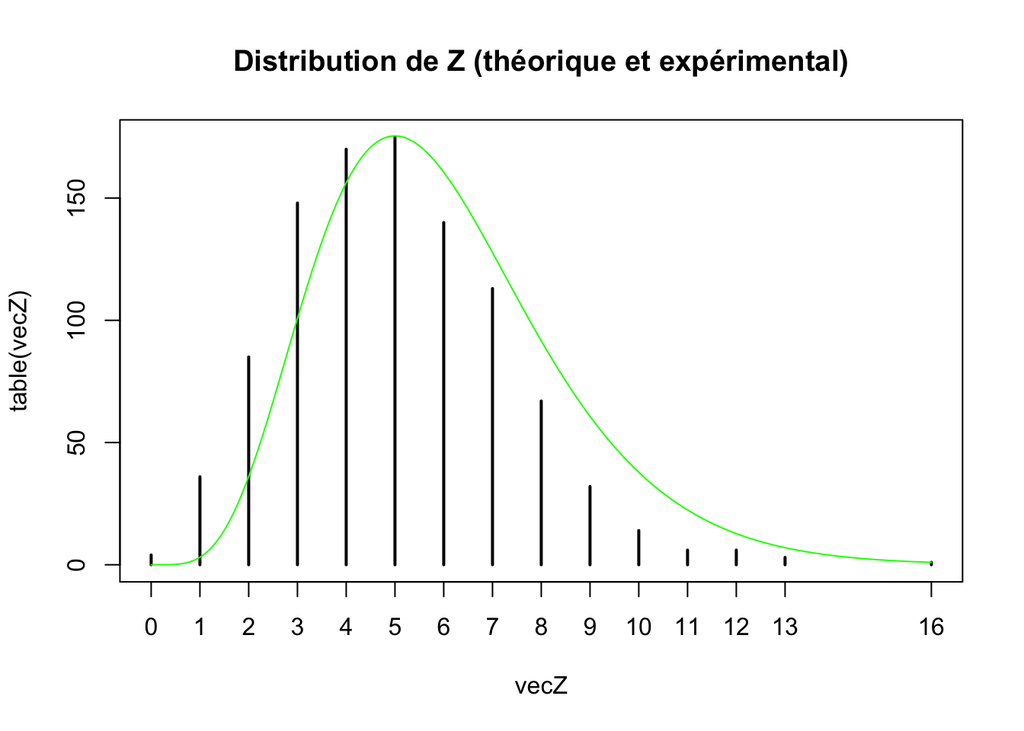

```r
#On utilise plot et pas barplot pour que cela corresponde à la densité théorique, les données sont les mêmes.
plot(table(vecZ),main='Distribution de Z (théorique et expérimental)')

#On donne des valeurs de x allant de 1 à 16
x = seq(0,16,0.1)

#On calcule la densité théorique pour chaque valeur
y = dpois(5,x)

#On ajoute la courbe à la distribution expérimentale. Le *1000 sert à mettre au même niveau les valeurs car on avait effectué 1000 réalisations de l'expérience.
lines(x,y*1000,col="green")
```

## Question 7

#### En guise d’exemple de la deuxième propriété que l’on cherche à illustrer, on se propose de représenter la distribution des observations de X lorsque Z=5.

a. Sélectionner les observations de X pour lesquelles la somme Z vaut 5.

```r
#On va stocker dans un vecteur 'new_vec' toutes les valeurs de X lorsque Z=5
new_vec<- NULL
for (i in 1:1000) { #On parcourt les 1000 réalisations de l'expérience
  if (vecZ[i]==5) #On vérifie la condition que Z = 5
  {
     new_vec <- c(new_vec,vecX[i]) #On ajoute la valeur de X à notre vecteur
  }
}

#Voici les valeurs obtenues :
new_vec
```

```
##   [1] 5 1 3 3 1 2 0 0 1 1 4 1 1 3 4 2 2 5 3 3 0 2 2 1 4 2 2 2 1 1 3 3 2 1 2 3 3
##  [38] 3 0 2 1 2 3 3 4 3 2 0 2 4 2 1 2 2 1 2 1 2 4 4 2 1 2 2 2 3 2 1 2 3 2 2 3 1
##  [75] 3 2 2 1 0 1 1 2 3 3 0 0 2 0 3 3 2 3 3 3 1 2 1 2 1 3 1 0 1 1 2 4 3 3 5 1 3
## [112] 2 2 1 4 3 3 2 2 1 1 1 0 3 1 2 2 1 1 1 3 3 1 3 3 4 3 2 2 4 1 0 3 1 0 2 2 4
## [149] 2 1 3 2 2 1 2 0 1 4 4 1 4 3 2 1 1 1 2 1 2 3 3 1 3 5 3
```

b. Représenter ensuite la distribution en fréquences des valeurs de X sachant Z=5.

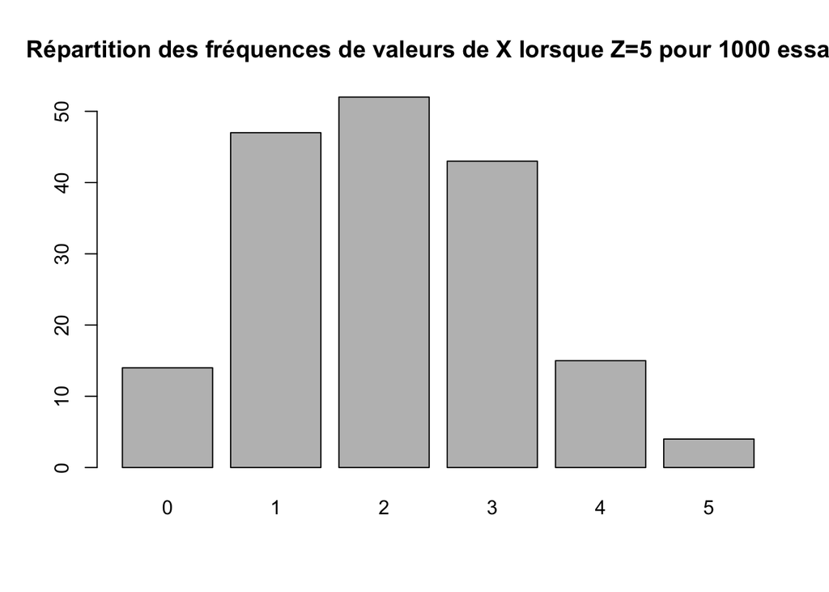

```r
barplot(table(new_vec),main="Répartition des fréquences de valeurs de X lorsque Z=5 pour 1000 essais")
```

c. Ajuster à la représentation précédente la distribution théorique de X|Z=n avec n=5

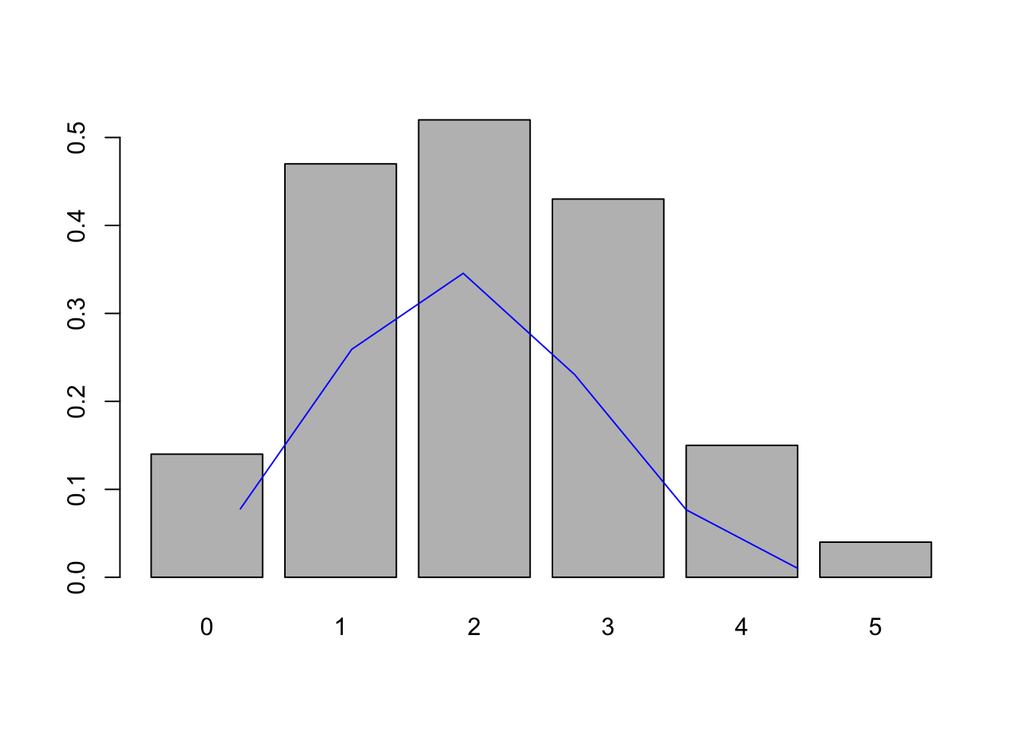

```r
barplot(table(new_vec)/100) #ou barplot ?

#On parcourt les valeurs possibles donc de 0 à 5 par pas de 1
x <- seq(0,5,1)

#On calcule pour chaque valeur la densité de la loi binomiale de paramètre 2/5
y <- dbinom(x,5,2/5)

#On ajoute au graphique précédent la courbe de y en fonction de x
lines(x+1,y,col='blue')
```

```r
#On met x+1 pour faire coincider le diagramme en barre et la courbe, sinon la courbe commence à l'origine et le résultat est moins exploitabale.
#On pourrait aussi enlever le x+1 et mettre 'plot' au lieu de 'barplot'.
```

# Exercice 3

### Deux guichets sont ouverts dans une banque : le temps de service au premier (resp. au second) guichet suit une loi exponentielle de moyenne 20 (resp. 30) minutes. On pose X le temps de service au premier guichet et Y le temps de service au second et l’on suppose que X et Y sont indépendantes.

## Question 8

#### Dans un premier temps, on se propose d’illustrer par simulation que Z=min(X,Y) suit une loi exponentielle de paramètre a+b où a et b sont les paramètres de X et Y respectivement.

a. Générer un vecteur u (resp. v) qui reçoit 1000 réalisations aléatoires de X (resp. de Y).

```r
#Guichet 1
u <- c(rexp(1000,1/20))

#Guichet 2
v <- c(rexp(1000,1/30))
```

b. Représenter la distribution ainsi simulée de Z.

```r
#On affecte les valeurs minimales à un vecteur z
z <- pmin(u,v)

#Aperçu de 3% des valeurs de z :
z[0:30]
```

```
##  [1] 27.7393041  5.6763102 11.2795995  0.1082563  7.6918847 50.8810624
##  [7] 14.5094072 17.9912689  5.4099181  1.3742086 24.2451524  3.5807213
## [13] 23.4538727 36.2711810 14.6820744 23.1902647  3.6648353  0.9217423
## [19]  1.7989158  2.1809388  4.7642903  4.8221548  6.9378089  8.8004652
## [25]  5.6939200  2.0989180  2.9543100 10.5135927  4.9583801  9.3231115
```

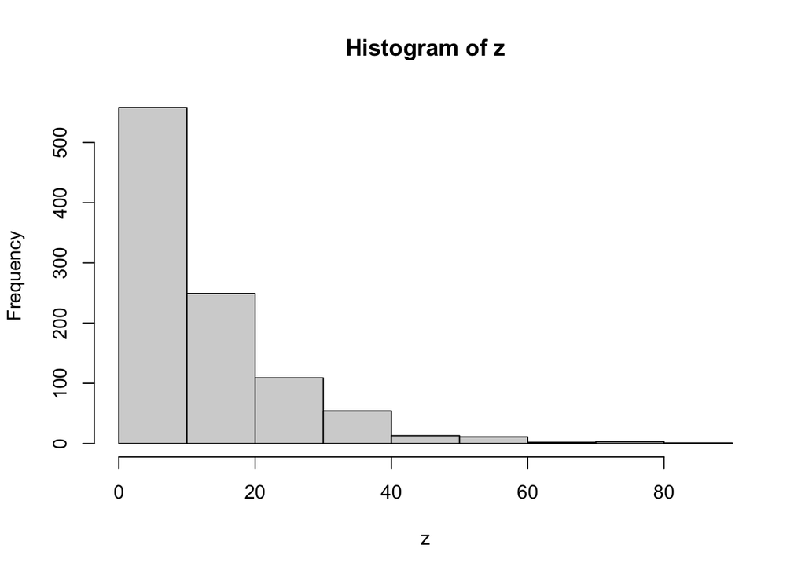

```r
hist(z)
```

c. Sur le même graphe, représenter la densité d’une loi exponentielle de paramètre a+b.

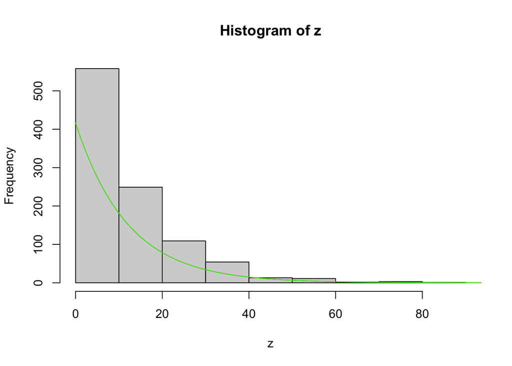

```r
hist(z)
x_exp = seq(0,1000,0.1)

#En utilisant la fonction dexp()
y_exp = dexp(x_exp,1/12) #car a + b => 1/20 + 1/30 => 1/12

#En utilisant la définition de la densité d'une loi exponentielle
y_exp2 = 1/12*exp(-1/12*x_exp)

lines(x_exp,y_exp*5000,col='red')
lines(x_exp,y_exp2*5000,col='green')
```

```r
#On multiplie par 5000 pour avoir des proportions cohérentes
#En vert on voit la représentation théorique
#On remarque que les courbes vertes et rouges sont bien confondues donc les 2 méthodes fonctionnent.
```

## Question 9

#### Aude et Vincent sont convoqués pour s’expliquer sur leurs découverts respectifs. Aude choisit le premier guichet et Vincent le second.

a. Evaluer à l’aide du logiciel la probabilité que Aude sorte avant Vincent.

```r
#Soit u le vecteur stockant les nombre de minutes de 1000 sorties de Aude (resp. v pour Vincent)

#Ici on créé une boucle qui compte le nombre de fois ou l'événement Aude sort avant apparait.
cpt_aude_sort_avant <- 0
for (i in 1:1000)
{
  if (u[i] == z[i]) #Lorsque que Aude a le temps minimum
  {
        cpt_aude_sort_avant <- cpt_aude_sort_avant + 1
  }
}
#Nombre de fois où Aude sort avant Vincent :
cpt_aude_sort_avant
```

```
## [1] 613
```

```r
#Probabilité que Aude sorte avant Vincent :
cpt_aude_sort_avant/1000
```

```
## [1] 0.613
```

b. Déterminer par un calcul la valeur théorique de la probabilité précédente.

#### On considère l’événement A : Aude sorte avant Vincent.

$$P(A) = \frac{\frac{1}{20}}{\frac{1}{20}+\frac{1}{30}} = 0,6$$

#### On retombe bien sur la probabilité obtenue dans la question précédente.

c. Evaluer la probabilité que les deux soient sortis au bout de 20 minutes.

```r
#Voici une boucle qui permet de compter le nombre de fois ou les deux sortent avant 20 minutes
cpt_avant_20_min <- 0
for (i in 1:1000)
{
  if (u[i]<20 && v[i]<20) #Lorsque les temps d'Aude et Vincent sont inférieurs à 20
  {
        cpt_avant_20_min <- cpt_avant_20_min + 1
  }
}

#Nombre de fois où les 2 sortent avant 20 minutes :
cpt_avant_20_min
```

```
## [1] 315
```

```r
#Probabilité que les 2 sortent avant 20 minutes :
cpt_avant_20_min/1000
```

```
## [1] 0.315
```

```r
#En realité ici on ne fait que dénombrer le nombre d'apparition d'un événement. (Apparition divisé par le nombre de répétition)
```

## Question 10

#### Soit t⩾0. On cherche à évaluer la probabilité que les deux soient sortis au temps t. En posant M=max(X,Y), il s’agit donc de déterminer FM(t)=ℙ[max(X,Y)⩽t].

a. À partir des données simulées, représenter la fonction de répartition empirique de M. On pourra utiliser la fonction ecdf.

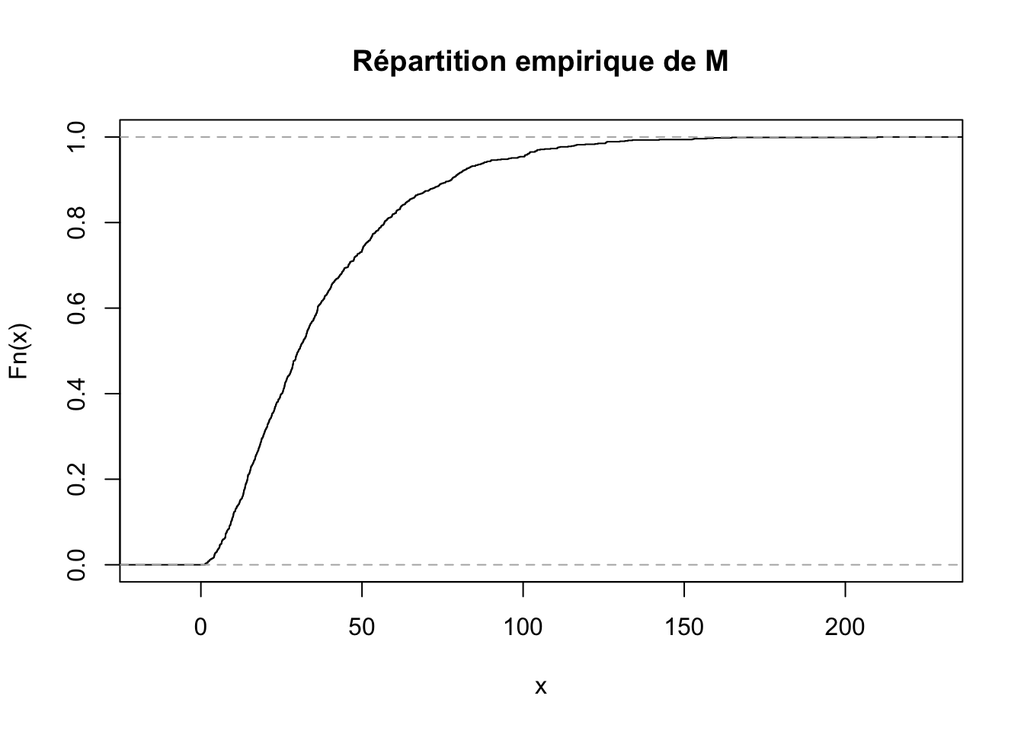

```r
#Le vecteur M prend les valeurs max entre u et v
M <- pmax(u,v)

plot(ecdf(M),main='Répartition empirique de M')
```

b. Exprimer FM en fonction de FX et FY, puis en déduire une expression de FM(t) en fonction de t.

On cherche à déterminer une fonction de repartition de M

Fm(t)= fx = P[X<=t] si x<fy donc si u<v fy = P[Y<=t] sinon

C’est à dire :

$$\mathbb{P}[M<t] = \mathbb{P}[X<=t]~OU~\mathbb{P}[Y<=t]$$
Donc
$$F_{M}(t) = F_X(t) + F_Y(t)$$
Donc
$$F_M(t) = \frac{1}{20}* exp(-\frac{t}{20}) + \frac{1}{30}* exp(-\frac{t}{30})$$

D’une autre manière en utilisant R on pourrait créer une fonction Fm qui calcule en fonction de t et du maximum la fonction de répartition :

```r
fm = function(t){
  for (k in 1:100)
  {
    if (M[k] == u[k]) # Dans le cas où x>y
    {
      #Fm = Fx
      return(pexp(t,1/20))
    }
    else
    {
      #Fm = Fy
      return(pexp(t,1/30)) #Dans le cas où y>x
    }
  }
}

#On peut tester la fonction avec t = 10 minutes :
fm(10)
```

```
## [1] 0.2834687
```

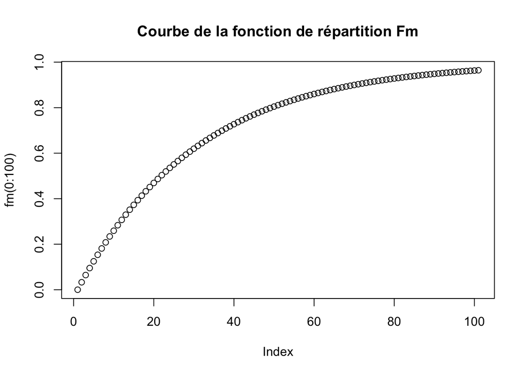

```r
#Bonus : Voici un aperçu de la courbe de la fonction Fm
plot(fm(0:100),main='Courbe de la fonction de répartition Fm')
```